Tweede beweging · Verschillen koppelen

# Hoofdstuk 4 — Het rechthoekje

Covariantie, correlatie en enkelvoudige regressie

> **Grove schets.** Dit hoofdstuk opent boek-beweging 2 met de **terugkeer-scène** (de dieren zien het patroon: groot glanst *meestal* — uit de schatkistje-splitsing 5-7; de vondst staat in H1 §2, de kraai-diefstal sluit dít hoofdstuk als cliffhanger naar H5). Kern: **armen-scène → product → rechthoek → covariantie → twee brillen (r en b)**. Het woord *regressie* valt hier voor het eerst. Y = **glans** (besluit 5-7, was prijs).

> Bronnen: Bens armen-uitleg (chat 4-7-2026, verbatim-kern hieronder verwerkt), Bib `uitleg-correlatie-gevoel-kwadranten-aapjes-min-min-is-plus`, `uitleg-covariantie-product-van-twee-afwijkingen`, kiem drie-schrijfwijzen (MVDA-opfris). Getallen doorgerekend en kloppend met kompas (r = .578, b = 32.1).

## 1. De terugkeer

GROF — terugkeer-scène; de vondst zelf staat nu in H1 §2 (schatkistje-splitsing 5-7). Kern-dialoog uit het oorspronkelijke verhaal, herpunt op samenhang. Stem-pas volgt.

De volgende ochtend lagen de diamantjes nog op het mos.

De kraai pakte er één met haar snavel en hield ’m tegen het licht. “Deze is groot. En glanst behoorlijk.”

“Maar deze is kleiner en glanst meer,” zei de bever, wijzend.

“En deze is groot, maar… saai,” zei de meeuw.

De olifant keek een tijdje over alle twaalf heen, zoals alleen olifanten kijken — zonder haast, zonder iets aan te raken.

“De grote glanzen meestal meer,” zei hij toen. “Meestal.”

En daar lag, midden in dat *meestal*, die ene grote doffe.

*Meestal.* Dat woord gaat dit hoofdstuk dragen. Niet *altijd* — meestal. De grote glanzen meestal meer; groot gaat meestal samen met glanzend. Dat is een nieuwe soort waarneming: niet over één diamantje, ook niet over het gemiddelde diamantje, maar over hoe hun verschillen *met elkaar meedoen*. Een verschil tussen verschillen — precies waar hoofdstuk 1 op eindigde.

## 2. De wolk en haar midden

Terug naar de puntenwolk waarmee hoofdstuk 1 sloot: karaat op de ene as, glans op de andere, twaalf punten. Statistici noemen het kruispunt van de twee gestreepte lijnen — de gemiddelde karaat, de gemiddelde glans — de *centroïde*: het zwaartepunt van de wolk. En op dat kruispunt woont — bij ons, bij toeval, niet bij wet — iemand. **Else.** Tot op de komma de gemiddelde diamant; dat wisten we sinds hoofdstuk 1, inclusief de eerlijke voetnoot: de centroïde is meestal een leeg adres, en onze wolk heeft toevallig een bewoner.

En Else gaat ons in dit hoofdstuk iets leren dat bijna niemand over het gemiddelde weet. In hoofdstuk 1 had ze geen vierkantje — haar gokfout was nul. Straks blijkt ze ook geen rechthoekje te hebben. Wie précies gemiddeld is, doet aan geen enkele berekening mee: **de statistiek ziet alleen verschil, en Else verschilt van niets.** Ze zegt niks. Ze telt alleen mee — in de twaalf. GROF: dit dieper uitspelen bij redactie-pas; Wilde-lijn: het gemiddelde zijn maakt je niet het middelpunt, het maakt je onzichtbaar. En de n-pointe: ze verandert geen enkele schatting, wél de zekerheid — “ze zegt niks, maar ze telt”.

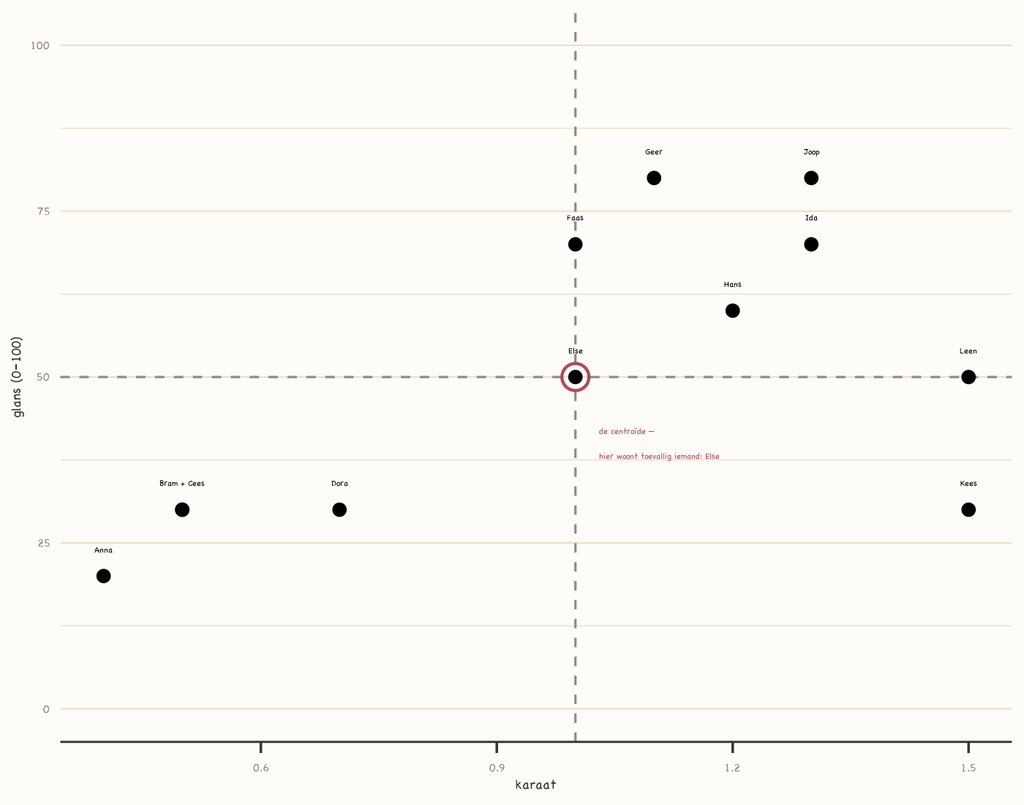

Figuur v1. De twee gestreepte lijnen delen de wolk in vier vakken — benoemen, maar het woord “kwadrant” pas in sectie 3 laten vallen.

Vanaf dat kruispunt gaan we kijken. Niet naar de wolk in één keer — naar één diamantje tegelijk.

## 3. Hoog of laag? — de armen

Dit is de dragende scène van het hoofdstuk. Bens bord-scène, hier in docenten-stem. In de klas doet hij dit letterlijk met zijn armen — dat beeld moet de tekst in; zie open punt “armen-tekening”.

Pak een willekeurig diamantje uit de wolk. Eerste vraag: zit hij **hoog of laag op karaat**? Alleen links-rechts kijken dus — en de hoogte even volledig negeren. Dat is lastiger dan het klinkt: je ogen willen de hele positie zien, maar ik vraag maar één as tegelijk.

Zeg dat het antwoord *laag* is. In de klas laat ik dan mijn rechterarm hangen — laag, en een beetje bungelen, overdreven graag.

Tweede vraag, zelfde diamantje: **en op glans — hoog of laag?** Ook laag. Daar gaat mijn linkerarm: ook omlaag, ook bungelen. Twee armen, dezelfde kant op.

Nu een diamantje rechtsboven in de wolk. Hoog op karaat — arm omhoog. Hoog op glans — andere arm ook omhoog. Weer twee armen dezelfde kant op, alleen nu allebei de lucht in.

> *Wat hadden deze twee diamantjes gemeen?*

In de klas laat ik jullie hier even spartelen. Bij jou kan ik alleen de bladzijde stilhouden. GROF — hier een leespauze/witruimte; Ben laat ze in de klas bewust even spartelen.

Niet hun positie — de één zat linksonder, de ander rechtsboven. Wat ze gemeen hadden: **beide armen wezen dezelfde kant op.** Laag-laag en hoog-hoog zijn, voor deze vraag, hetzelfde soort diamantje: eentje die op beide assen dezelfde richting koos.

En dan zijn er diamantjes waar de armen elkaar tegenspreken: hoog op karaat, laag op glans. Eén arm omhoog, één omlaag. Kees. Maar nog niet bij naam — die komt in sectie 4 terug.

Laatste vraag van de scène: **welk diamantje beweegt op béíde variabelen het extreemst?** Niet wie op één as het verst zit — wie op allebei tegelijk ver van het midden zit. Om “ver op X” en “ver op Y” in één getal te vangen heb je een *product* nodig. Vermenigvuldigen. En als je twee afstanden vermenigvuldigt, krijg je —

daar is-ie weer: een **oppervlakte**.

## 4. De rechthoek

In hoofdstuk 1 maakten we van elke gokfout een *vierkantje*: de afwijking keer zichzelf. Nu hebben we per diamantje twéé gokfouten — eentje op karaat, eentje op glans. Vermenigvuldig die met elkaar en je krijgt geen vierkant maar een **rechthoek**: breedte = de karaat-afwijking, hoogte = de glans-afwijking.

$$(X_i - \overline{X})(Y_i - \overline{Y})$$

Term-blokje: kruisproduct / cross product. Even-terug-blokje: een vierkant is een rechthoek waarvan de zijden toevallig gelijk zijn — de covariantie van een variabele met zichzélf is de variantie. Dat is de brug terug naar H1 en vooruit naar alles.

Die rechthoek kan drie dingen zijn:

- **Positief** — beide armen dezelfde kant op (laag-laag of hoog-hoog: min × min = plus, plus × plus = plus).
- **Negatief** — armen tegengesteld (hoog-laag of laag-hoog: plus × min = min).
- **Niets** — en dit is de belangrijkste van de drie. Wie op één van de twee assen precies gemiddeld is, heeft een rechthoek met een zijde van nul. Geen oppervlakte. *Co* betekent *samen* — wie maar op één variabele afwijkt, varieert niet samen. Die doet niet mee.

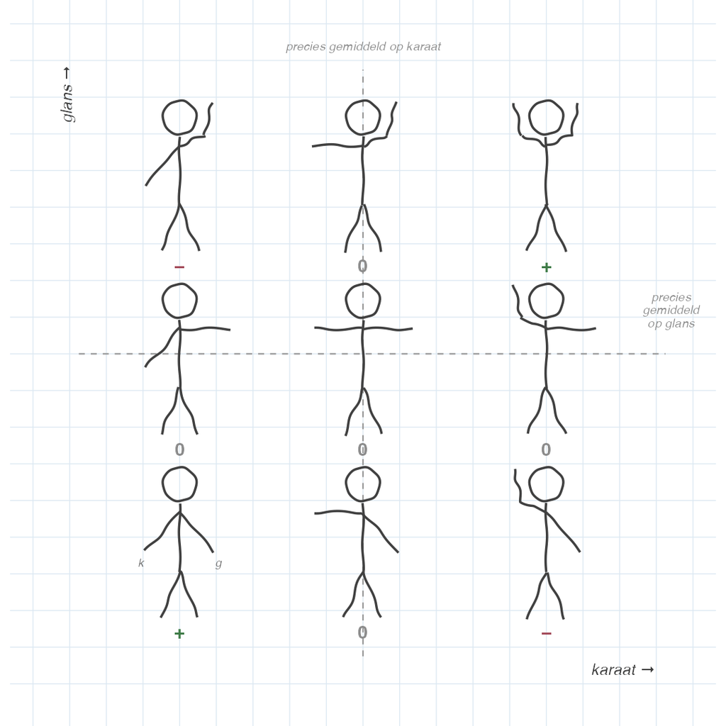

Figuur v1 (R-steiger, `02_figuren/_poppetjes_wolk_proef.R`, 6-7) — alle negen armen-houdingen in één wolk: 3×3 (laag/midden/hoog op karaat × idem op glans), bijdrage-teken eronder in decompositie-kleuren (+ groen, − bordeaux, 0 grijs). *k* = karaat-arm, *g* = glans-arm (gemarkeerd op het laag-laag-poppetje). Eindversie tekent Ben zelf — ILLUSTRATIES.md poses 1–4.

Bij twaalf diamantjes kunnen we gewoon even tellen wie wat bijdraagt:

**Tabel 4.1.** *De twaalf kruisproducten (“rechthoekjes”).*

| naam | karaat-residu | glans-residu | rechthoek | bijdrage |
| --- | --- | --- | --- | --- |
| Anna | −0.6 | −30 | +18 | positief |
| Bram | −0.5 | −20 | +10 | positief |
| Cees | −0.5 | −20 | +10 | positief |
| Dora | −0.3 | −20 | +6 | positief |
| Else | 0 | 0 | 0 | **niets** — zit óp het kruispunt |
| Faas | 0 | +20 | 0 | **niets** — wijkt alleen op glans af |
| Geer | +0.1 | +30 | +3 | positief |
| Hans | +0.2 | +10 | +2 | positief |
| Ida | +0.3 | +20 | +6 | positief |
| Joop | +0.3 | +30 | +9 | positief |
| Kees | +0.5 | −20 | **−10** | negatief — dáár is hij weer |
| Leen | +0.5 | 0 | 0 | **niets** — wijkt alleen op karaat af |

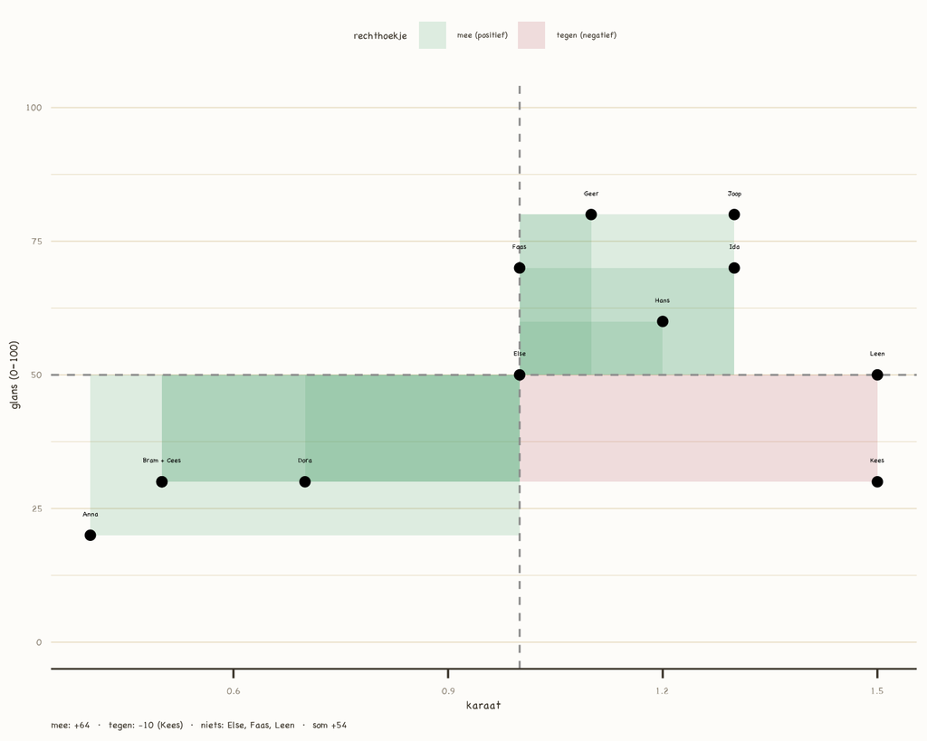

Figuur v1 — het visuele hart van het hoofdstuk: elke diamant spant zijn rechthoek naar de centroïde; groen wint zichtbaar van bordeaux, en de drie zonder oppervlakte doen niet mee.

Wie wint? De positieven halen samen 64, Kees haalt 10 terug, drie diamantjes doen niet mee. Som: **+54**. De wolk leunt dus duidelijk één kant op: groter gaat samen met glanzender. Kees protesteert, maar hij verliest.

En dan doen we wat we altijd doen met een som: delen door het aantal échte vrije gokfouten. Het *gemiddelde rechthoekje*:

$$\begin{aligned}
S_{XY} &= \frac{\sum (X_i - \overline{X})(Y_i - \overline{Y})}{n-1} \\
&= \frac{54}{11} \\
&= 4.91
\end{aligned}$$

Dit getal heet de **covariantie**. Gemiddeld samen-bewegen. Het is voor de samenhang wat de variantie voor de spreiding was: de motor. En net als de variantie heeft het één probleem.

## 5. Ruw is ruk — de eerste bril

Wat ís 4.91? De eenheid is karaat-keer-glanspunten. Niemand denkt in karaat-glanzen. Bib: “dit is een ruwe samenhangsmaat. En ruw is ruk.” Had de glansmeter een schaal tot duizend gehad in plaats van honderd, dan stond hier 49.1 — tien keer zo veel samenhang, zonder dat er íéts aan de wolk veranderde.

De oplossing kennen we uit hoofdstuk 1: delen door de spreiding. Alleen — we hebben er nu twee. Dus delen we door allebei:

$$\begin{aligned}
r_{XY} &= \frac{S_{XY}}{S_X \cdot S_Y} \\
&= \frac{4.91}{0.39 \times 21.74} \\
&= .58
\end{aligned}$$

Dit is de **correlatie**. Eenheidloos, altijd tussen −1 en +1. GROF: guess-the-correlation-gevoel hier — wolkjes tonen, laten gokken; −1 = alle punten exact op een dalende lijn, 0 = ronde wolk, +1 = stijgende lijn. Bib-unit beschikbaar.

Kijk nog eens wat er staat: boven de deelstreep een oppervlakte (het gemiddelde rechthoekje, 4.91), en eronder óók een — de rechthoek die je twee lineaaltjes samen opspannen, 0.39 × 21.74 = 8.50. $r$ zegt dus hoe vaak het gemiddelde rechthoekje in die lineaaltjes-rechthoek past: .58 keer.

Noem dit de **psychologische bril**: je gooit de eenheden weg en houdt puur de *sterkte* van het samen-bewegen over. Vergelijkbaar over alle onderzoeken, alle meetlatten, alle vragenlijsten. De prijs die je betaalt: je weet niet meer hoevéél.

## 6. De tweede bril — de lijn

Er is nog een manier om diezelfde motor te lezen. Niet delen door beide spreidingen, maar alleen door de variantie van karaat:

$$\begin{aligned}
b &= \frac{S_{XY}}{S^2_X} \\
&= \frac{4.91}{0.153} \\
&= 32.1
\end{aligned}$$

Kijk naar wat er met de eenheden gebeurt: karaat-keer-glans gedeeld door karaat-kwadraat = **glans per karaat**. Dit getal zégt iets, in gewone woorden: elke karaat erbij is gemiddeld 32 glanspunten erbij.

Noem dit de **natuurkundige bril**: je houdt de eenheden juist vást, en je krijgt er een *richtingscoëfficiënt* voor terug — een lijn door de wolk.

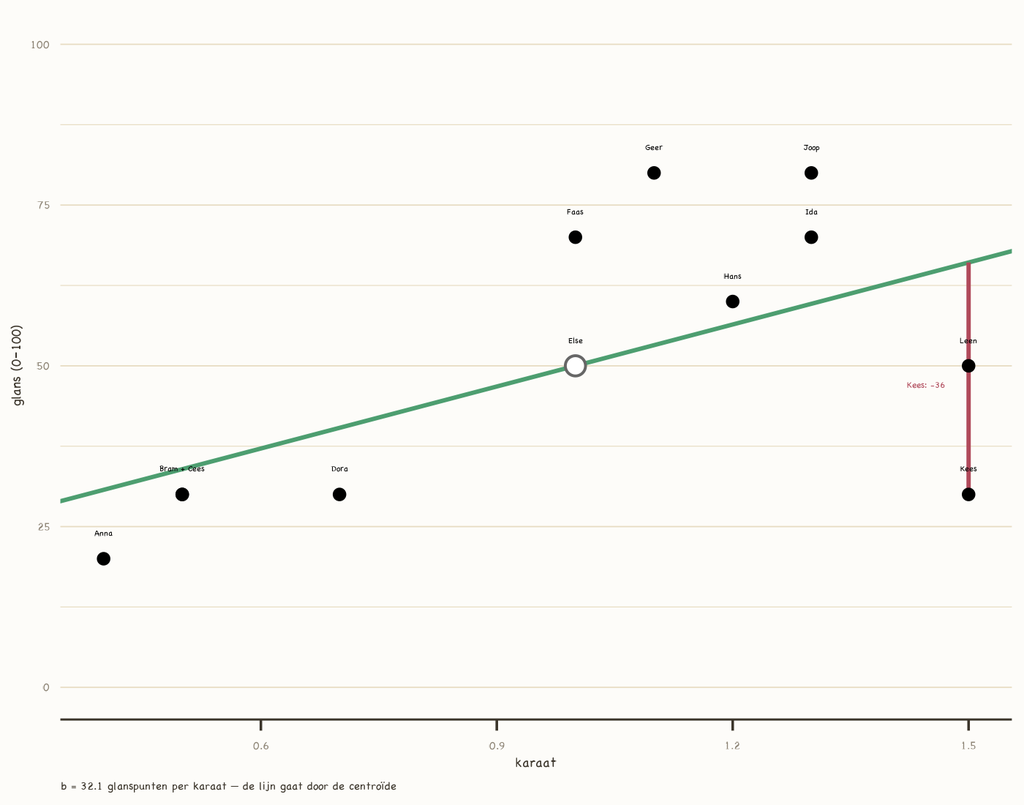

Figuur v1.

En hier valt het woord: de lijn die zo door de wolk loopt dat de gokfouten zo klein mogelijk zijn, heet de **regressielijn**. “Zo klein mogelijk” is daarbij precies wat je uit hoofdstuk 1 verwacht: niet de gokfouten zelf (die sommeren toch naar nul, plus en min heffen elkaar op), maar hun *vierkantjes* — de lijn maakt de som van de gekwadrateerde gokfouten zo klein als hij kan. Statistici noemen dat de **kleinste-kwadraten-lijn**. Waarom het woord *regressie* — dat verhaal komt nog. Regressie-naar-de-mean + Wilde-lijn: latere pas of H5+.

**kleinste kwadraten** *least squares (OLS)*

Eén motor, twee brillen. Zelfde teller, andere noemer:

- ÷ beide spreidingen → **r** — hoe stérk bewegen ze samen (eenheidloos)
- ÷ variantie van X → **b** — hoevéél Y per eenheid X (in eenheden)

En de twee brillen laten zich in elkaar omrekenen: $b = r \cdot \frac{S_Y}{S_X}$ — neem de sterkte, en zet hem terug in eenheden. Reken maar na: op een afrondinkje na rolt er 32.1 uit. Zelfde motor, andere jas.

### Even over dat woordje *per*

Lees de eenheid van *b* nog eens hardop: **32.1 glanspunten per karaat.**

Daar staat iets wat je al je hele leven kunt. Je koopt kaas voor €8.50 per kilo. Je rijdt 90 kilometer per uur. Een huis kost €3200 per vierkante meter. Dat zijn allemaal **verschillen per verschil** — een verschil in het ene, gedeeld door een verschil in het andere. Niemand noemt ze zo, en iedereen rekent ermee.

Dus dit is geen nieuw soort getal. Het is een kiloprijs, met glans in plaats van euro’s:

|  | wat het zegt | wat het **niet** zegt |
| --- | --- | --- |
| €8.50 per kilo | 1 kilo meer kost €8.50 meer | niet elk stuk kaas kost €8.50 — dat hangt van het gewicht af |
| 90 km per uur | 1 uur langer is 90 km verder | je bent niet elk uur 90 km verder — je stopt voor een stoplicht |
| **32.1 glans per karaat** | 1 karaat zwaarder gaat samen met 32.1 glanspunten meer | **niet elke zwaardere steen is feller — dat is Kees** |

Die rechterkolom is belangrijker dan de linker, en dit is waarom. Een tarief zegt iets over *hoe de verschillen samen bewegen*, niet over wat er met een bepaald geval gebeurt. Bij de kaas is dat vanzelfsprekend. Bij een regressielijn vergeet zo ongeveer iedereen het, en dan gaat 32.1 klinken als een belofte aan elke afzonderlijke steen.

Kijk nog even naar de voorzetsels, want ze staan er alle drie in: verschil **in** glans **per** verschil **in** karaat, **tussen** de diamantjes onderling. In wijst de variabelen aan, tussen wijst de stenen aan, en per zegt hoe de twee met elkaar meebewegen. De eenheid is de docent.

Even-terug-blokje: en het vierkant? Deel de covariantie-van-X-met-zichzelf door $S^2_X$ en er staat 1 — elke variabele volgt zichzelf perfect. De hele familie is één formule.

En Kees? Kees ligt onder de lijn. De lijn loopt namelijk dwars door het midden van de wolk — waaróm, dat zie je in de volgende sectie — dus vanaf Else (karaat 1.0, glans 50) is het naar Kees (1.5) een halve karaat klimmen: 50 + 0.5 × 32.1 ≈ 66, zegt de lijn. Hij glanst 30. Zijn gokfout is −36 — veel groter dan zijn afstand tot het kale gemiddelde eerst leek. Onthoud die −36 maar even; in sectie 8 vraag ik hem terug.

De totale gokfout van elke diamant — precies de blauwe streepjes uit hoofdstuk 1 — valt nu in twee stukken uiteen: het stuk dat de lijn verklaart, en het stuk dat overblijft.

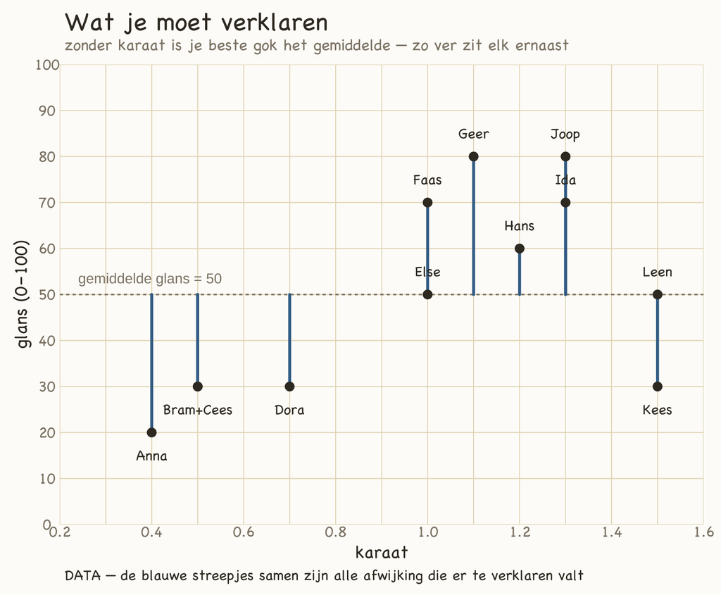

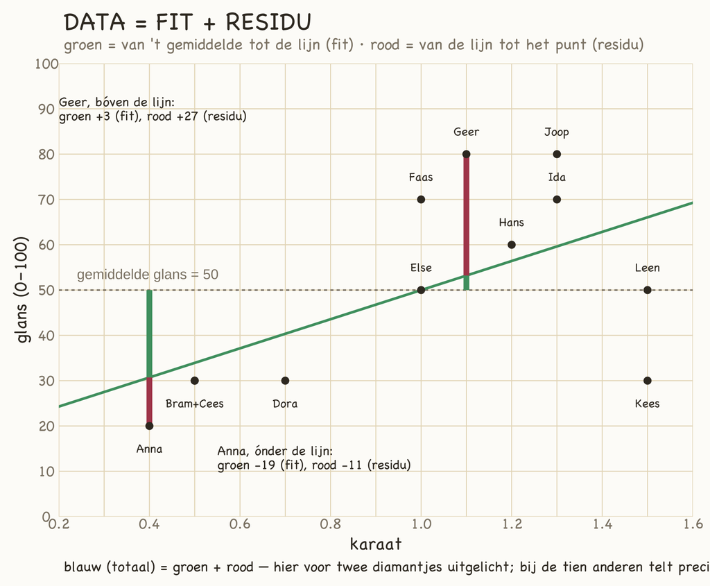

## 7. De hele lijn — en waar hij begint

Eén getal is nog geen lijn. 32.1 is een *richting* — maar er zijn oneindig veel lijnen met die richting, allemaal netjes evenwijdig, de wolk in en uit. Welke is de onze?

Het antwoord is de belofte uit sectie 6: de regressielijn gaat áltijd door de centroïde — door het kruispunt van de twee gemiddelden. Bij ons: dwars door Else heen. Alweer Else. En alweer merkt ze er niets van.

Maar “de lijn met richting 32.1 door Else” is geen formule waar iemand anders wat mee kan. Daarvoor heeft een lijn een startpunt nodig: waar hij de verticale as raakt, bij karaat nul. Vanaf nu krijgt onze 32.1 daarom een huisnummer — $b_1$ — want er komt een tweede b bij wonen: $b_0$, het **intercept**. Dat startpunt vind je door vanaf de centroïde gewoon terug te lopen:

$$\begin{aligned}
b_0 &= \overline{Y} && -\ b_1\overline{X} \\
&= 50 && -\ 32.1 \times 1.0 \\
&= 17.9
\end{aligned}$$

Samen zijn ze de hele lijn:

**intercept** *intercept, constant* notatie: $b_0$

$$\begin{aligned}
\hat{Y} &= b_0 && +\ b_1 X \\
&= 17.9 && +\ 32.1 \times X
\end{aligned}$$

Hoe je deze formule leest:

- $\hat{Y}$ — spreek uit “Y-dakje”. Het dakje betekent: dit is niet wat we *zagen*, maar wat de lijn *gokt*. De voorspelde glans.
- $b_0$ — waar de lijn begint (de glans-gok bij karaat nul): 17.9.
- $b_1$ — hoeveel de lijn stijgt per karaat: 32.1 glanspunten.

Lees als: *begin bij 17.9, en tel er 32.1 bij op voor elke karaat.*

Betekent dat intercept iets? Wees eerlijk: een diamant van nul karaat is een diamant die er niet is, en die zou 17.9 glanzen. Onzin dus. $b_0$ is bij ons geen uitspraak over de wereld — het is het ankerpunt van de lijn, meer niet. Dat is vaker wel dan niet zo: een intercept mág betekenis hebben, maar hij hoeft niet.

Wat de formule wél kan: **voorspellen**. Stel, de dam vangt morgen een dertiende diamant, 1.2 karaat, en je moet zijn glans gokken vóór iemand de glansmeter erbij pakt:

$$\hat{Y} = 17.9 + 32.1 \times 1.2 \approx 56$$

Dat is je gok. Hans — óók 1.2 karaat — glanst 60, vier punten erboven; zo dichtbij en zo ver zit je dus met zo’n gok. En check meteen de route via Kees uit sectie 6: 17.9 + 32.1 × 1.5 ≈ 66 — dezelfde 66 als daarnet vanaf Else geteld. Eén lijn, twee routes.

En nu het eerlijke verhaal, alvast in één zin: dit voorspellen — een individu een getal geven — is het enige dat de lijn écht toevoegt boven de correlatie. En we doen het bijna nooit. In sectie 12 maken we de rekening op.

Nog één ding, over de ton. Onze twee b’s zijn uitgerekend op het kistje — twaalf diamantjes. In de ton (alle diamanten die de dam óóit zou kunnen vangen) loopt óók een lijn, en zoals altijd krijgen de populatie-tegenhangers Griekse letters: $\beta_0$ en $\beta_1$ (“beta”). Onze $b_0$ en $b_1$ zijn schattingen van die $\beta_0$ en $\beta_1$ — statistieken die parameters schatten, de Levi’s 501 uit hoofdstuk 1. Maar let op, en dit is de waarschuwing die we in hoofdstuk 1 al aankondigden: in artikelen wordt β óók gebruikt voor iets ánders — de *gestandaardiseerde* coëfficiënt, een b in lineaaltjes-eenheden. Twee betekenissen, één letter, eeuwige verwarring. Bij ons is β voorlopig alleen dit: dezelfde b, maar dan van de hele ton.

## 8. DATA = FIT + RESIDU

In hoofdstuk 1 speelden we het grabbel-spel: blind een diamant trekken, gokken met het gemiddelde, en kijken hoe ver je ernaast zat. Nu spelen we het opnieuw — maar je mag éérst kijken. Niet naar de glans; wel naar de karaat. Je gok is niet langer voor iedereen 50; je gok is wat de líjn zegt bij die karaat.

Daarmee valt elke glans uiteen in twee stukken: het stuk dat de lijn al wist, en het stuk dat de diamant zelf inbrengt.

$$Y_i = \hat{Y}_i + e_i \qquad \text{oftewel} \qquad \text{DATA} = \text{FIT} + \text{RESIDU}$$

FIT is de voorspelling — het punt óp de lijn. RESIDU is de gokfout — het stukje ernaast, $e_i = Y_i - \hat{Y}_i$. Dit is geen nieuwe formule maar een nieuwe *lezing*: elk datapunt is een stukje model plus een stukje eigenwijsheid. Deze splitsing gaat de rest van het boek dragen.

Voor Kees: de lijn zegt 66, hij glanst 30.

$$\underbrace{30}_{\text{DATA}} = \underbrace{66}_{\text{FIT}} + \underbrace{(-36)}_{\text{RESIDU}}$$

En voor alle twaalf:

**Tabel 4.2.** *DATA = FIT + RESIDU voor alle twaalf diamantjes.*

| naam | karaat | glans (DATA) | op de lijn (FIT) | ernaast (RESIDU) |
| --- | --- | --- | --- | --- |
| Anna | 0.4 | 20 | 30.7 | −10.7 |
| Bram | 0.5 | 30 | 33.9 | −3.9 |
| Cees | 0.5 | 30 | 33.9 | −3.9 |
| Dora | 0.7 | 30 | 40.4 | −10.4 |
| Else | 1.0 | 50 | 50.0 | 0 |
| Faas | 1.0 | 70 | 50.0 | +20.0 |
| Geer | 1.1 | 80 | 53.2 | +26.8 |
| Hans | 1.2 | 60 | 56.4 | +3.6 |
| Ida | 1.3 | 70 | 59.6 | +10.4 |
| Joop | 1.3 | 80 | 59.6 | +20.4 |
| Kees | 1.5 | 30 | 66.1 | −36.1 |
| Leen | 1.5 | 50 | 66.1 | −16.1 |

Getallen doorgerekend met b₁ = 54/1.68 = 32.14 (afronding op één decimaal — vandaar 66.1 in de tabel naast “≈ 66” in de tekst); t.z.t. borgen in het waarheidsscript, samen met de Kees-vierkantjes uit sectie 9 en de R²-afronding uit sectie 10 (één afrondingsregime kiezen: alles vanaf de tabel-decimalen, óf alles exact en pas aan het eind afronden).

Pak je rekenmachientje en reken er twee zelf na — Anna en Geer. Anna: 17.9 + 32.1 × 0.4 = 30.7, en 30.7 + (−10.7) = 20. Klopt haar rij? En die van Geer? Elke rij van deze tabel moet optellen: FIT + RESIDU = DATA, zonder uitzondering.

Een paar oude bekenden staan er opeens anders bij. **Else**: de lijn gaat door haar heen, FIT 50, residu 0 — geen vierkantje in hoofdstuk 1, geen rechthoekje in sectie 4, en nu ook geen residu. Wie van niets verschilt, verschilt ook van geen enkele lijn. **Faas** hangt recht boven haar: de lijn gokt voor hem gewoon het gemiddelde, dus zijn hele afwijking is eigenwijsheid. En **Leen** — die had in hoofdstuk 1 geen vierkantje, want zijn glans was precies 50. Maar de lijn verwácht meer van een grote diamant: 66. Nu heeft hij opeens een residu van −16. Gemiddeld zijn is niet genoeg meer zodra iemand je karaat kent.

En Kees. Onder het kale gemiddelde zat hij −20; onder de lijn −36. De lijn maakt de meeste gokfouten kleiner — vergelijk de RESIDU-kolom maar eens met de gokfouten uit hoofdstuk 1 — maar die van Kees, en van Leen zagen we net, juist gróter. Dat is geen foutje van de lijn; dat is informatie. Hoe beter het model, hoe scherper de uitzondering in beeld komt. Onthoud hem, nog steeds.

O ja: tel de RESIDU-kolom eens op. Nul (op afronding na). De residuen houden elkaar rond de lijn precies zo in evenwicht als ze dat in hoofdstuk 1 rond het gemiddelde deden. Sommige dingen verhuizen gewoon mee.

## 9. Het streepjes-spel

Terug naar figuur 1.1 — de twaalf blauwe streepjes, elke glans aan het gemiddelde vastgemaakt. Die streepjes gaan we nu opknippen. De schaar is de lijn.

Elk **blauw** totaal-streepje (van het punt naar $\overline{Y}$) valt uiteen in een **groen** fit-streepje (van de lijn naar $\overline{Y}$ — het stuk dat de lijn overbrugt) en een **bordeaux** residu-streepje (van het punt naar de lijn — het stuk dat overblijft):

$$\underbrace{(Y_i - \overline{Y})}_{\text{blauw: totaal}} = \underbrace{(\hat{Y}_i - \overline{Y})}_{\text{groen: fit}} + \underbrace{(Y_i - \hat{Y}_i)}_{\text{bordeaux: residu}}$$

GROF — figuur h4_streepjes_knip nog te tekenen: de wolk met de regressielijn en de gemiddelde-lijn; per diamant het blauwe totaal-streepje opgeknipt in groen (gemiddelde→lijn) en bordeaux (lijn→punt); Kees en Geer prominent, Else zonder streepje

Check het bij Kees: blauw −20 = groen +16 + bordeaux −36. Bij hem vechten de twee stukken — de lijn duwt hem omhoog (groot! dus vast glanzend!) en de werkelijkheid trekt hem hard terug. En reken Geer zelf na: blauw +30 = groen 3.2 + bordeaux 26.8. Bij Geer doet de lijn bijna niets; zijn glans is vrijwel helemaal van hemzelf.

En nu de beweging die je uit hoofdstuk 1 kent: kwadrateren en optellen. Eerst één eerlijke waarschuwing: per diamant tellen de *streepjes* op, de *vierkantjes* niet — bij Kees is blauw² = 400, maar groen² + bordeaux² = 259 + 1303 (reken maar na met zijn rij uit tabel 4.2: 16.1² en 36.1²). Per individu klopt de vierkantjes-boekhouding dus níét. Maar tel je over alle twaalf tegelijk, dan klopt hij opeens wél, exact:

$$SS_{\text{totaal}} = SS_{\text{regressie}} + SS_{\text{residu}}$$

$$5200 = 1736 + 3464$$

$SS_{\text{totaal}}$ ken je trouwens al: dat is gewoon $SS_Y$ uit hoofdstuk 1, de 5200 — alle blauwe vierkantjes samen. Die tuin is nu in tweeën gedeeld: een groen deel dat óp de lijn ligt, en een bordeaux deel dat ernaast valt. Dat dit precies opgaat is geen afrondingsgeluk: de kleinste-kwadraten-lijn is exact zó gekozen dat fit en residu niets meer van elkaar weten — wat de lijn al zegt, zit niet nog eens in de fouten. GROF — de kruisterm-uitleg (waarom hij wegvalt) is een kandidaat “Voor wie verder wil”-kader — Bens call

GROF — figuur h4_ss_spel nog te tekenen: het SS-jes-spelletje als oppervlaktes. Variant A: de blauwe glans-tuin van 5200 met daarbinnen het groene stuk van 1736 en het bordeaux stuk van 3464 — zelfde drie getallen als de streepjes, nu als vlakken. Variant B (Venn): cirkel karaat en cirkel glans die elkaar overlappen; de overlap is wat ze delen. Keuze bij de figuren-ronde

Drie getallen. Ze betalen samen de twee cadeaus van de volgende sectie.

## 10. Twee cadeaus uit de splitsing

### Het residu-lineaaltje — $S_e$

**standaardschattingsfout** *standard error of the estimate* notatie: $S_e$ ook: residu-lineaaltje

In hoofdstuk 1 was de *SD* je lineaaltje: hoe ver zit een diamant er gemiddeld naast als je gokt met het gemiddelde — 21.74 glanspunten. Nu we met de lijn gokken, willen we hetzelfde lineaaltje opnieuw, maar dan róónd de lijn: hoe ver zit een diamant er gemiddeld naast als je zijn karaat kent?

Zelfde recept als altijd: neem de vierkantjes van de gokfouten (dat is $SS_{\text{residu}}$, de bordeaux 3464), deel door het aantal écht vrije gokfouten, en trek de wortel. Alleen — hoeveel gokfouten zijn er nog vrij? In hoofdstuk 1 kostte het gemiddelde ons één envelopje: $n-1$. De lijn is duurder: ze ligt pas vast met *twee* getallen, $b_0$ en $b_1$. Twee envelopjes open, dus $n-2$ vrije gokfouten.

$$\begin{aligned}
S_e &= \sqrt{\frac{SS_{\text{residu}}}{n-2}} \\
&= \sqrt{\frac{3464}{10}} \\
&= 18.6
\end{aligned}$$

Dit is de **standaardschattingsfout** — maar laat de naam je niet foppen: dit is géén standaardfout van een bordje uit hoofdstuk 3. Het is gewoon een standaardafwijking, van de residuen. De *SD* was je meetlat rond het gemiddelde; $S_e$ is exact diezelfde meetlat, verhuisd naar de lijn. Het residu-lineaaltje.

En kijk wat er gebeurd is: 21.74 is 18.6 geworden. De meetlat is korter — dát is wat kennis van de karaat je koopt. Had de lijn niets geholpen, dan was $S_e$ vrijwel gewoon de *SD* gebleven: karaat kennen had je dan niets gekocht. Veel korter is hij trouwens ook nu niet geworden, en ook dat is eerlijke informatie: karaat weet iets van glans, maar lang niet alles. Dit is nog steeds gewoon meten en beschrijven — geen orakel, geen uitspraak over de ton.

### VAF — hoeveel van de tuin staat in het gelid

**verklaarde variantie** *variance accounted for (VAF)* notatie: $R^2$ ook: determinatiecoëfficiënt, $r^2$

Het tweede cadeau is een verhouding. Deel het groene stuk van de tuin door de hele tuin:

$$\begin{aligned}
R^2 &= \frac{SS_{\text{regressie}}}{SS_{\text{totaal}}} \\
&= \frac{1736}{5200} \\
&= .33
\end{aligned}$$

Dit heet de **verklaarde variantie**, of *variance accounted for* — VAF. Het aandeel van alle glans-variatie dat de lijn voor zijn rekening neemt. In hoofdstuk 1 beloofden we het al: verklaarde variantie is het stuk van de tuin waar strakke rijtjes bloemen staan. Hier staat het rijtje — het ís de lijn. Een derde van de glans-tuin staat in het gelid; twee derde groeit wild, bordeaux, ernaast.

En nu de vondst die de twee brillen definitief aan elkaar klinkt. Kwadrateer de correlatie eens — pak wel de onafgeronde, .578: $.578^2 = .33$. Precies hetzelfde getal. (Kwadrateer je de afgeronde .58, dan rolt er .34 uit — dat honderdste is puur afronding, geen wiskunde.) Bij één voorspeller is $R^2$ gewoon $r^2$ — de oppervlakte-lezing van sectie 5, nog één keer, nu van de andere kant bekeken. De eerste bril zei *hoe sterk*; kwadrateer haar en ze zegt *hoeveel van de tuin*. Eén motor, en inmiddels de derde uitlezing.

## 11. Wat de lijn stilzwijgend veronderstelt

Eén ding hebben we dit hele hoofdstuk gedaan zonder het hardop te zeggen: we hebben een *réchte* lijn door de wolk gelegd. Dat is geen neutrale handeling — het is een veronderstelling. Op het moment dat je een rechte lijn kiest, beweer je dat het verband recht ís: elke karaat erbij is evenveel glans erbij, onderaan de wolk net zo goed als bovenaan. De wolk zelf mag krom zijn; onze lijn kan het niet. Leg je een rechte lijn op een gebogen verband, dan liegt elke voorspelling een beetje — netjes, systematisch, en zonder dat één getal je waarschuwt. Daarom is de eerste controle altijd de domste en de beste: kíjk naar de wolk. Bij onze twaalf oogt recht heel redelijk. GROF — mini-voorbeeldje krom verband (leren oefenen? slaap en prestatie?) bij redactie-pas — Bens call

Er horen nog drie veronderstellingen bij dit soort lijnen, alle drie over de residuen: dat ze *onafhankelijk* van elkaar zijn, dat hun spreiding overal langs de lijn even groot is (*gelijke spreiding* — het deftige woord is homoscedasticiteit, leer het alvast hardop zeggen), en dat ze *normaal verdeeld* zijn. Voor nu alleen de namen: die drie werken we pas bij meervoudige regressie echt uit. Onthoud het onderscheid: de lijn zélf eist alleen rechtheid; de rest gaat over hoe de fouten zich gedragen — en de fouten worden pas echt belangrijk als we méér van de lijn gaan vragen dan beschrijven.

## 12. Eerlijk — wat heb je nu eigenlijk gekregen?

Tijd voor de ontnuchtering.

Enkelvoudige regressie is de correlatie plus een voorspel-formuletje. Meer niet. Alles wat de lijn je over het *verband* vertelde, wist $r$ eigenlijk al: dezelfde motor, dezelfde sterkte, dezelfde richting. Het meestal-gevoel van de olifant — groot glanst meestal meer — was met .58 al compleet. Het enige dat de lijn er écht aan toevoegt is dat je een individu een getal kunt geven: 1.2 karaat, dan gok ik 56. En wees eerlijk: wanneer moet een psycholoog voor het laatst één iemands glans voorspellen? Bijna nooit. In de psychologie willen we meestal het *meestal* begrijpen, niet één geval raden. Daarvoor was de eerste bril genoeg.

Waarom dan toch dit hele hoofdstukdeel? Omdat de lijn het skelet is waar straks alles aan komt te hangen. Eén voorspeller is een oefenlijn. Regressie wordt pas echt de bom als er méér voorspellers meedoen — dan kan de lijn iets wat de correlatie principieel niet kan: een tweede variabele *vasthouden* terwijl je naar de eerste kijkt. Wegrekenen. Corrigeren. Dat is de derde beweging van dit boek, en daar is alles wat je hier leerde — FIT, RESIDU, de streepjes, de tuin — het handgereedschap voor.

En nog één ding, voor de volledigheid. $r$, $b_1$ en de lijn zijn geen drie apparaten — het is één motor met drie uitlezingen. Wie zich dus afvraagt of dit *meestal* echt is, of alleen een toevalstreffer van déze twaalf, stelt één vraag, niet drie. Hoe je die vraag beantwoordt — daar komen we later op terug. Bewust vaag in de lezerstekst — maar de beslissing is inmiddels genomen (H5-schets, status-header, Bens besluit 5 juli): inferentie landt in H5 en wordt geleerd óp b en r, interval vóór toets.

## 13. Werk

Het rekenen mét software — R en JASP — hoort bij het R-oefenboek: *het boek toont, het oefenboek traint.* Covariantie, correlatie en de regressielijn (`cov`, `cor`, `lm`) doe je daar met je eigen data.

Software-vrij (7-7, keuzes §1). Kiem (cov/cor/lm + geom_smooth + de rechthoekjes-figuur; nu ook `predict`/`resid`, de DATA=FIT+RESIDU-tabel en de streepjes-knip-figuur): `03_oefenboek_kiemen/R_werk_uit_schetsen_2026-07-11.md`.

## 14. Sluiting

GROF — docent-slot: de olifant had het al gezien vóór wij gingen rekenen — groot gaat meestal samen met glanzend. Wij weten nu hoe sterk (.58), hoevéél (32 per karaat), hoe ver we er dan nog naast zitten (het residu-lineaaltje, 18.6) en welk deel van de tuin de lijn bijhoudt (een derde). Dan de slotscène:

Toen pakte de kraai er stiekem eentje mee, en vloog weg.

De anderen keken haar na. Niemand zei iets.

GROF — en de docent-uitademing daaroverheen: Elf diamantjes. Morgen misschien tien. Onze wolk was nooit de hele wereld — het was wat er toevallig in een beverdam bleef hangen. Zou het patroon er nog zijn met een andere twaalf? Met elf? Hoe zeker zijn we eigenlijk van dat *meestal*?

Dat is het volgende hoofdstuk. De grabbelton staat al klaar.